# Lab5: Deployment: Model-agnostic methods

2023-04-28

Authors: Victoria Peiró Vidal, Alejandro Bueno Gonzalez, Vicente Torres Martínez.

## 1.- One dimensional Partial Dependence Plot.

The partial dependence plot shows the marginal effect of a feature on the predicted outcome of a previously fit model.

**EXERCISE:** Apply PDP to the regression example of predicting bike rentals. Fit a random forest approximation for the prediction of bike rentals (cnt). Use the partial dependence plot to visualize the relationships the model learned. Use the slides shown in class as model.

```r
day <- read_csv("day.csv")
# One-hot encoding for season
day_feat <- cbind(day[c("cnt", "workingday", "holiday")], data.frame(model.matrix(~factor(season) - 1, day))[c(1,3:4)])
colnames(day_feat)[4:6] <- c("Winter", "Summer", "Fall")

# MISTY feature
day_feat$MISTY <- ifelse(day$weathersit == 2, 1, 0)

# RAIN feature
day_feat$RAIN <- ifelse(day$weathersit %in% c(3, 4), 1, 0)

# Denormalized temp, hum, and windspeed
day_feat$dtemp <- day$temp * (39 - (- 8)) + (-8)
day_feat$dhumidity <- day$hum * 100
day_feat$dwindspeed <- day$windspeed * 67

# Create a feature (days_since_2011)
day_feat$days_since_2011 <- as.numeric(as.Date(day$dteday, "%Y-%m-%d") - as.Date("2011-01-01")) + 1
```

```r
library(randomForest)
day.rfor <- randomForest(cnt ~ ., data = day_feat)
day.pred <- predict(day.rfor, data = day_feat)
```

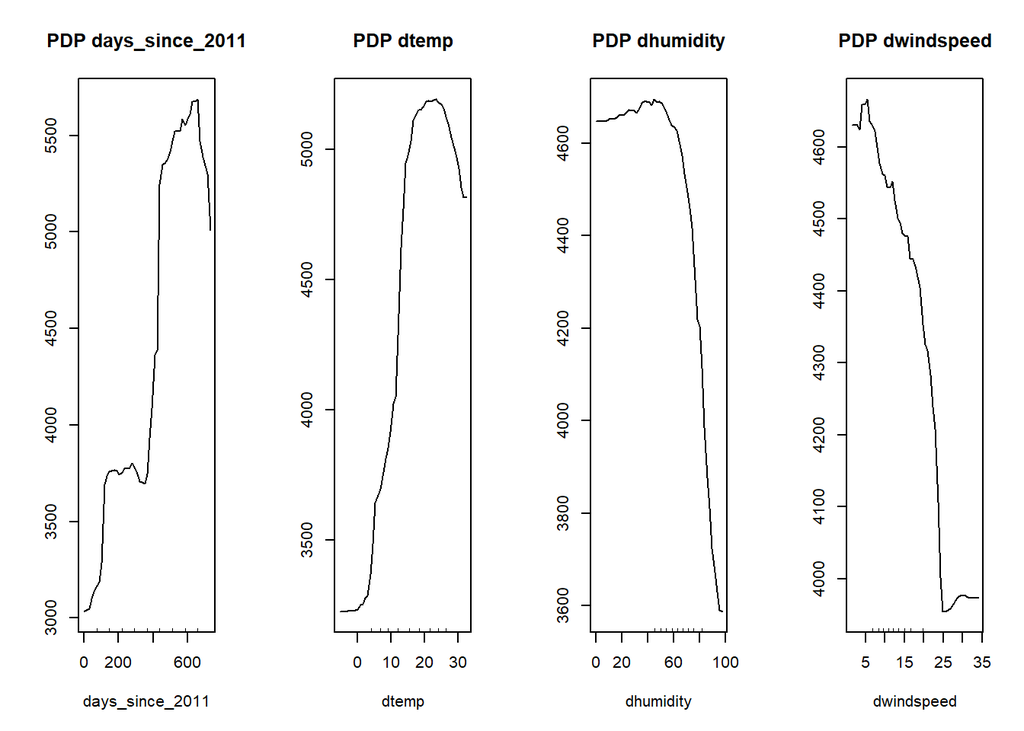

```r
library(pdp)
day_var <- c("days_since_2011", "dtemp", "dhumidity", "dwindspeed")
op <- par(mfrow=c(1, 4))
for (i in seq_along(day_var)) {
  partialPlot(day.rfor,
              day_feat,
              day_var[i],
              xlab = day_var[i],
              main = paste("PDP", day_var[i]))
}
```

```r
par(op)
```

**QUESTION:** **Analyse the influence of days since 2011, temperature, humidity and wind speed on the predicted bike counts.**

The variable days_since_2011 shows an incremental positive influence on the prediction of the number of bikes rented over time. It does not evolve in a linear fashion, as there appears to be a large increase in rentals, followed by a period of stability and then a few days of decline, before starting the cycle again.

Temperature (dtemp) seems to have a positive and more linear influence as its value increases from 0ºC to 18-25ºC. This suggests that bike rentals may be less common in extreme temperatures, such as very cold or very hot weather.

On the other hand, humidity (dhumidity) has a negative correlation with the number of rented bikes. Once the humidity value exceeds 40 and 50, the number of rentals decreases significantly. This could be, again, linked to extreme weather conditions, where people whose rental use tends to be occasional might choose other options.

Finally, wind speed (dwindspeed) shows a negative influence which could be roughly linear. Where if it exceeds 5 km/h, the number of bicycle rentals again decreases drastically, bearing in mind that it can be risky to cycle in windy environments.

## 2.- Bidimensional Partial Dependency Plot.

**EXERCISE:** Generate a 2D Partial Dependency Plot with humidity and temperature to predict the number of bikes rented depending on those parameters.

BE CAREFUL: due to the size, extract a set of random samples from the BBDD before generating the data for the Partial Dependency Plot.

Show the density distribution of both input features with the 2D plot as shown in the class slides.

TIP: Use geom_tile() to generate the 2D plot. Set width and height to avoid holes.

```r
set.seed(111)
nsam <- sample_n(day_feat, 100)
day_sam <- day_feat[c(rownames(nsam)),]
day_th <- inner_join(day_sam["dtemp"], day_sam["dhumidity"], by=character())
day_th$tofill <- 0
```

```r
for(i in 1:nrow(day_th)){
  df <- day_feat
  df$dtemp <- day_th[i, "dtemp"]
  df$dhumidity <- day_th[i, "dhumidity"]
  res <- predict(day.rfor, df)
  day_th[i, "tofill"] <- mean(res)
}
```

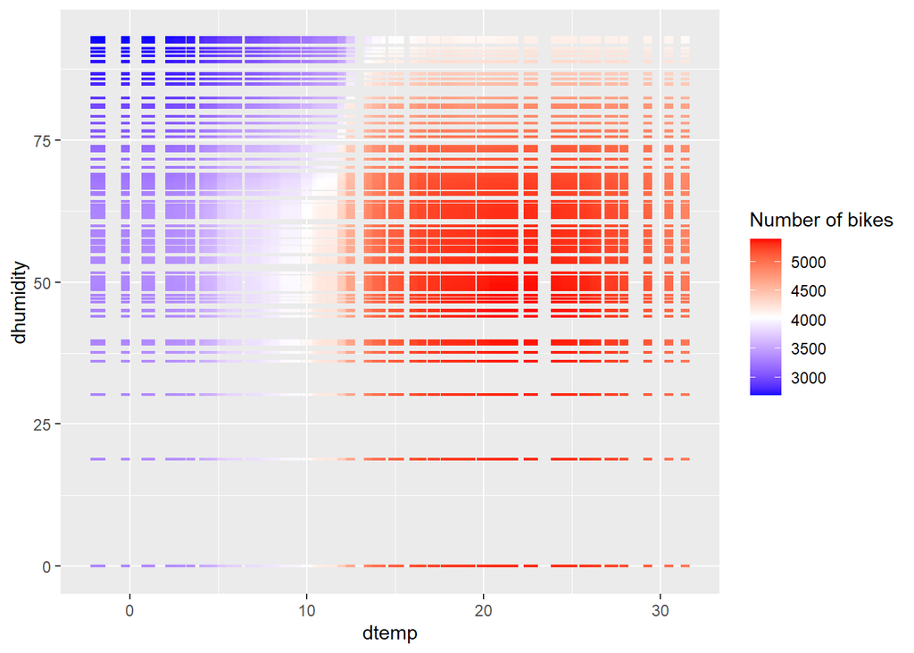

```r
ggplot(day_th, aes(x = dtemp, y = dhumidity, fill = tofill)) +
  geom_tile(width=0.5, height=0.5) +
  scale_fill_gradientn(colors = c("blue", "white", "red")) +
  guides(fill = guide_colourbar(title = "Number of bikes"))
```

**QUESTION:** **Interpret the results.**

## 3.- PDP to explain the price of a house.

**EXERCISE:** Apply the previous concepts to predict the price of a house from the database kc_house_data.csv. In this case, use again a random forest approximation for the prediction based on the features bedrooms, bathrooms, sqft_living, sqft_lot, floors and yr_built. Use the partial dependence plot to visualize the relationships the model learned.

BE CAREFUL: due to the size, extract a set of random samples from the BBDD before generating the data for the Partial Dependency Plot.

```r
house <- read_csv("kc_house_data.csv")
library(randomForest)
house.fit <- randomForest(price ~ bedrooms + bathrooms + sqft_living + sqft_lot + floors + yr_built, data = house)
house.pred <- predict(house.fit, data = house)

house_var <- c("bedrooms", "bathrooms", "sqft_living", "sqft_lot", "floors", "yr_built")
indx <- sample(nrow(house), 500, replace = FALSE)
house_sam <- as.data.frame(house[indx,house_var])
```

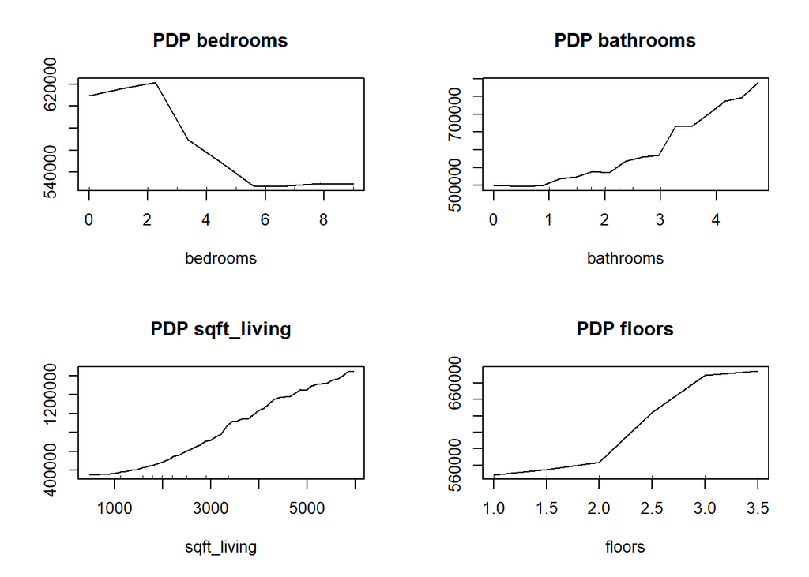

```r
library(pdp)
house_var <- c("bedrooms", "bathrooms", "sqft_living", "floors")
op <- par(mfrow=c(2, 2))
for (i in seq_along(house_var)) {
  partialPlot(house.fit,
              house_sam,
              house_var[i],
              xlab = house_var[i],
              main = paste("PDP", house_var[i]))
}
```

```r
par(op)
```

**QUESTION:** **Analyse the influence of bedrooms, bathrooms, sqft_living and floors on the predicted price.**

In the PDP plot for the influence of bedrooms in the price of houses seems to be negative for our case, therefore, as the number of rooms increases, the price decreases. On the other hand, the relationship between the number of bathrooms and the price is more linear and positive.

The amount of square feet of living space (sqft_living) seems to have a linear postive infleunce on the value of the price.

The influence of the number of floors on the price increases significantly more with a leap from 2 to 3, than with a leap from 1 to 2 floors.